# Reddit_Sentiment_Analysis

Kavya Deepthi Natta , Ajay Nawale

### **Title:**

- Reddit Sentiment Analysis

### **Team Members:**

- Kavya Deepthi Natta
- Ajay Nawale

### **Business Context:**

- Reddit is a link sharing, discussion, and community building platform. The main content on reddit are “posts”, which can only be submitted by users with a reddit account. A “link post” consists of a title that links to any page on the web (including links to other pages on reddit). A “text post” consists of a title and body of text. Both link and text posts have a comments section where other users can discuss the post. An equally important component to the functionality of reddit is the system of “subreddits”. Subreddits are categories and every post is placed into a single subreddit. Redditors subscribe to subreddits that interest, allowing them to follow specific types of content more closely.

### **Summarizing the dataset**

- The file that has been extracted from the Reddit has record count of ‘34768’ which has mix comments related to various vaccines like Pfizer, Morderna and Astrazeneca
- It has various features like post_id, post_author,post_title, post_score, comment(which is our most important feature), comment_date etc.
- We have also dropped few of the columns that were not contributing much to the sentiment analysis.

### **Importing Libraries**

```r
library(tidyverse)
library(tibble)
library(ggplot2)
library(readr)
library(dplyr)
library(tidyr)
library(tidytext)
library(RColorBrewer)
library(reshape2)
library(wordcloud)
library(igraph)
library(widyr)
library(ggraph)
library(ngram)
library(wordcloud2)
library(stringr)
library(ggplot2)
library(tm)
library(wordcloud)
library(knitr)
library(kableExtra)
library(tidytext)
library(tidyverse)
library(tibble)
library(ggplot2)
library(readr)
library(dplyr)
library(tidyr)
library(tidytext)
library(RColorBrewer)
library(reshape2)
library(wordcloud)
library(igraph)
library(widyr)
library(ggraph)
library(ngram)
library(wordcloud2)
library(stringr)
library(ggplot2)
library(tm)
library(wordcloud)
library(knitr)
library(kableExtra)
library(data.table)
library(lubridate)
library(wordcloud)
```

### **Setting the working directory**

```r
setwd(".")
getwd()
```

```
## [1] "C:/Users/ajayt/OneDrive/Desktop/CIS-8392/Reddit_Sentiment_Analysis_Project"
```

### **Reading the file**

```r
file = "Reddit_Comments.csv"
df <- fread(file)

Vaccine_file = "Vaccines.CSV"
df_Vaccine_file <- fread(Vaccine_file)

summary(df)
```

```
##    post_id          post_author         post_date          post_title
##  Length:34768       Length:34768       Length:34768       Length:34768
##  Class :character   Class :character   Class :character   Class :character
##  Mode  :character   Mode  :character   Mode  :character   Mode  :character
##
##
##
##    post_score    post_permalink       post_url          comment_id
##  Min.   :   94   Length:34768       Length:34768       Length:34768
##  1st Qu.:  467   Class :character   Class :character   Class :character
##  Median : 1228   Mode  :character   Mode  :character   Mode  :character
##  Mean   : 6790
##  3rd Qu.: 4635
##  Max.   :42481
##  comment_author     comment_date       comment_parent_id  comment_edited
##  Length:34768       Length:34768       Length:34768       Length:34768
##  Class :character   Class :character   Class :character   Class :character
##  Mode  :character   Mode  :character   Mode  :character   Mode  :character
##
##
##
##  comment_score     comment_body
##  Min.   :-153.00   Length:34768
##  1st Qu.:   1.00   Class :character
##  Median :   3.00   Mode  :character
##  Mean   :  17.65
##  3rd Qu.:  10.00
##  Max.   :9449.00
```

### **Glimpse of the dataset**

```r
row1 <- head(df, 1)
row1
```

```
##    post_id  post_author           post_date
## 1:  kdmkbz KinnerNevada 2020-12-15 14:21:20
##                                                                          post_title
## 1: Moderna's vaccine is highly effective, FDA says, clearing way for second vaccine
##    post_score
## 1:      42481
##                                                                   post_permalink
## 1: /r/Coronavirus/comments/kdmkbz/modernas_vaccine_is_highly_effective_fda_says/
##                                                                                                             post_url
## 1: https://www.nbcnews.com/health/health-news/moderna-vaccine-appears-protect-against-coronavirus-infection-n1251237
##    comment_id comment_author        comment_date comment_parent_id
## 1:    gfx8br4  AutoModerator 2020-12-15 14:21:21         t3_kdmkbz
##    comment_edited comment_score
## 1:          False             1
##                                                                                                                                                                                                                                                                                                          …
## 1: This post appears to be about vaccines, please see [our FAQ](https://www.reddit.com/r/Coronavirus/wiki/faq#wiki_where_can_i_find_information_about_the_mechanism_and_progress_of_vaccines.3F) for answers to frequently asked questions regarding the COVID-19 vaccines. Any comment containing misinf…
```

### **Data Summary**

#### 1.Total number of rows and columns in the dataset

```r
nrow(df)
```

```
## [1] 34768
```

```r
ncol(df)
```

```
## [1] 14
```

#### 2.The datatype of each column

```r
str(df)
```

```
## Classes 'data.table' and 'data.frame':   34768 obs. of  14 variables:
##  $ post_id          : chr  "kdmkbz" "kdmkbz" "kdmkbz" "kdmkbz" ...
##  $ post_author      : chr  "KinnerNevada" "KinnerNevada" "KinnerNevada" "KinnerNevada" ...
##  $ post_date        : chr  "2020-12-15 14:21:20" "2020-12-15 14:21:20" "2020-12-15 14:21:20" "2020-12-15 14:21:20" ...
##  $ post_title       : chr  "Moderna's vaccine is highly effective, FDA says, clearing way for second vaccine" "Moderna's vaccine is highly effective, FDA says, clearing way for second vaccine" "Moderna's vaccine is highly effective, FDA says, clearing way for second vaccine" "Moderna's vaccine is…
##  $ post_score       : int  42481 42481 42481 42481 42481 42481 42481 42481 42481 42481 ...
##  $ post_permalink   : chr  "/r/Coronavirus/comments/kdmkbz/modernas_vaccine_is_highly_effective_fda_says/" "/r/Coronavirus/comments/kdmkbz/modernas_vaccine_is_highly_effective_fda_says/" "/r/Coronavirus/comments/kdmkbz/modernas_vaccine_is_highly_effective_fda_says/" "/r/Coronavirus/comments/kdmkb…
##  $ post_url         : chr  "https://www.nbcnews.com/health/health-news/moderna-vaccine-appears-protect-against-coronavirus-infection-n1251237" "https://www.nbcnews.com/health/health-news/moderna-vaccine-appears-protect-against-coronavirus-infection-n1251237" "https://www.nbcnews.com/health/health…
##  $ comment_id       : chr  "gfx8br4" "gfx930g" "gfxaiv8" "gfxglf1" ...
##  $ comment_author   : chr  "AutoModerator" "Hothabanero6" "jsinkwitz" "TheyreGoodDogsBrent" ...
##  $ comment_date     : chr  "2020-12-15 14:21:21" "2020-12-15 14:28:43" "2020-12-15 14:42:16" "2020-12-15 15:36:09" ...
##  $ comment_parent_id: chr  "t3_kdmkbz" "t3_kdmkbz" "t3_kdmkbz" "t3_kdmkbz" ...
##  $ comment_edited   : chr  "False" "False" "False" "False" ...
##  $ comment_score    : int  1 1784 1905 3503 326 151 147 757 573 43 ...
##  $ comment_body     : chr  "This post appears to be about vaccines, please see [our FAQ](https://www.reddit.com/r/Coronavirus/wiki/faq#wiki"| __truncated__ "Who's ahead in the pool for the third vaccine to be approved?" "\"\"asymptomatic infection was reduced by 63 percent after the first shot. \…
##  - attr(*, ".internal.selfref")=<externalptr>
```

### **Data cleansing**

#### Dropping column comment_edited as its not contributing much to the analysis

```r
df$comment_edited <- NULL
```

#### Formatting time

```r
df$post_date <- ymd_hms(df$post_date)
df$comment_date <- ymd_hms(df$comment_date)
```

#### Segregatting post_date into year, month and day which would be further used in the visualizations

```r
df$post_day <- wday(df$post_date,label = T)
df$post_month <- month(df$post_date,abbr = T,label = T)
df$post_year <- year(df$post_date)
(head(df,1))
```

```
##    post_id  post_author           post_date
## 1:  kdmkbz KinnerNevada 2020-12-15 14:21:20
##                                                                          post_title
## 1: Moderna's vaccine is highly effective, FDA says, clearing way for second vaccine
##    post_score
## 1:      42481
##                                                                   post_permalink
## 1: /r/Coronavirus/comments/kdmkbz/modernas_vaccine_is_highly_effective_fda_says/
##                                                                                                             post_url
## 1: https://www.nbcnews.com/health/health-news/moderna-vaccine-appears-protect-against-coronavirus-infection-n1251237
##    comment_id comment_author        comment_date comment_parent_id
## 1:    gfx8br4  AutoModerator 2020-12-15 14:21:21         t3_kdmkbz
##    comment_score
## 1:             1
##                                                                                                                                                                                                                                                                                                          …
## 1: This post appears to be about vaccines, please see [our FAQ](https://www.reddit.com/r/Coronavirus/wiki/faq#wiki_where_can_i_find_information_about_the_mechanism_and_progress_of_vaccines.3F) for answers to frequently asked questions regarding the COVID-19 vaccines. Any comment containing misinf…
##    post_day post_month post_year
## 1:      Tue        Dec      2020
```

#### Checking for nulls in the availble dataset

```r
colSums(is.na(df))
```

```
##           post_id       post_author         post_date        post_title
##                 0                 0                 0                 0
##        post_score    post_permalink          post_url        comment_id
##                 0                 0                 0                 0
##    comment_author      comment_date comment_parent_id     comment_score
##                 0                 0                 0                 0
##      comment_body          post_day        post_month         post_year
##                 0                 0                 0                 0
```

#### **Summary of the dataset**

```r
summary(df)
```

```
##    post_id          post_author          post_date
##  Length:34768       Length:34768       Min.   :2020-11-20 11:51:35
##  Class :character   Class :character   1st Qu.:2020-12-02 07:02:59
##  Mode  :character   Mode  :character   Median :2020-12-15 09:25:35
##                                        Mean   :2020-12-17 10:31:27
##                                        3rd Qu.:2020-12-30 19:32:07
##                                        Max.   :2021-01-17 12:40:13
##
##   post_title          post_score    post_permalink       post_url
##  Length:34768       Min.   :   94   Length:34768       Length:34768
##  Class :character   1st Qu.:  467   Class :character   Class :character
##  Mode  :character   Median : 1228   Mode  :character   Mode  :character
##                     Mean   : 6790
##                     3rd Qu.: 4635
##                     Max.   :42481
##
##   comment_id        comment_author      comment_date
##  Length:34768       Length:34768       Min.   :2020-11-20 12:00:08
##  Class :character   Class :character   1st Qu.:2020-12-02 13:56:32
##  Mode  :character   Mode  :character   Median :2020-12-15 15:53:57
##                                        Mean   :2020-12-17 19:28:20
##                                        3rd Qu.:2020-12-31 16:55:25
##                                        Max.   :2021-01-17 19:49:26
##
##  comment_parent_id  comment_score     comment_body       post_day
##  Length:34768       Min.   :-153.00   Length:34768       Sun:4464
##  Class :character   1st Qu.:   1.00   Class :character   Mon:6044
##  Mode  :character   Median :   3.00   Mode  :character   Tue:5959
##                     Mean   :  17.65                      Wed:5006
##                     3rd Qu.:  10.00                      Thu:5063
##                     Max.   :9449.00                      Fri:4831
##                                                          Sat:3401
##    post_month      post_year
##  Dec    :19281   Min.   :2020
##  Jan    : 8413   1st Qu.:2020
##  Nov    : 7074   Median :2020
##  Feb    :    0   Mean   :2020
##  Mar    :    0   3rd Qu.:2020
##  Apr    :    0   Max.   :2021
##  (Other):    0
```

### **Data Visualization**

#### 1.Posts by year

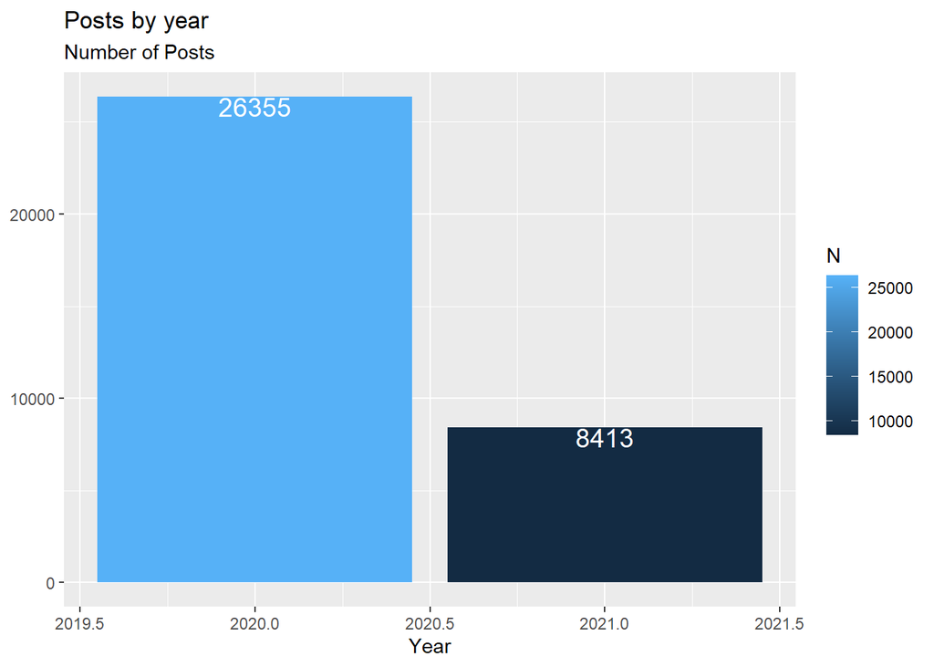

```r
ggplot(df[,.N,by=post_year],aes(x = post_year,y = N,fill=N, label=round(N,2)))+
  geom_bar(stat = "identity")+
  labs(title="Posts by year",subtitle="Number of Posts")+
  xlab("Year")+
  ylab(NULL)+
  geom_text(size=5, vjust=1, color="white")
```

#### 2.Posts by month

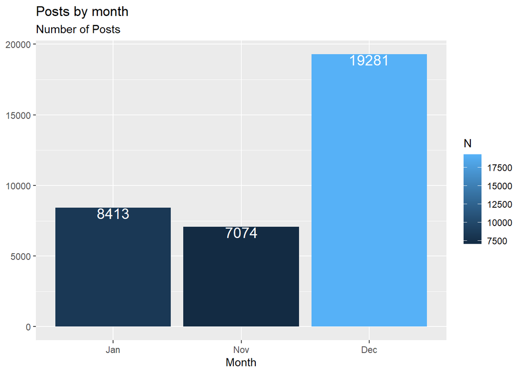

```r
ggplot(df[,.N,by=post_month],aes(x = post_month,y = N,fill=N, label=round(N,2)))+
  geom_bar(stat = "identity")+
  labs(title="Posts by month",subtitle="Number of Posts")+
  xlab("Month")+
  ylab(NULL)+
  geom_text(size=5, vjust=1, color="white")
```

#### Inference

- It can be seen from the graph that the month of December had the highest number of comments.

#### 3.Posts by Day

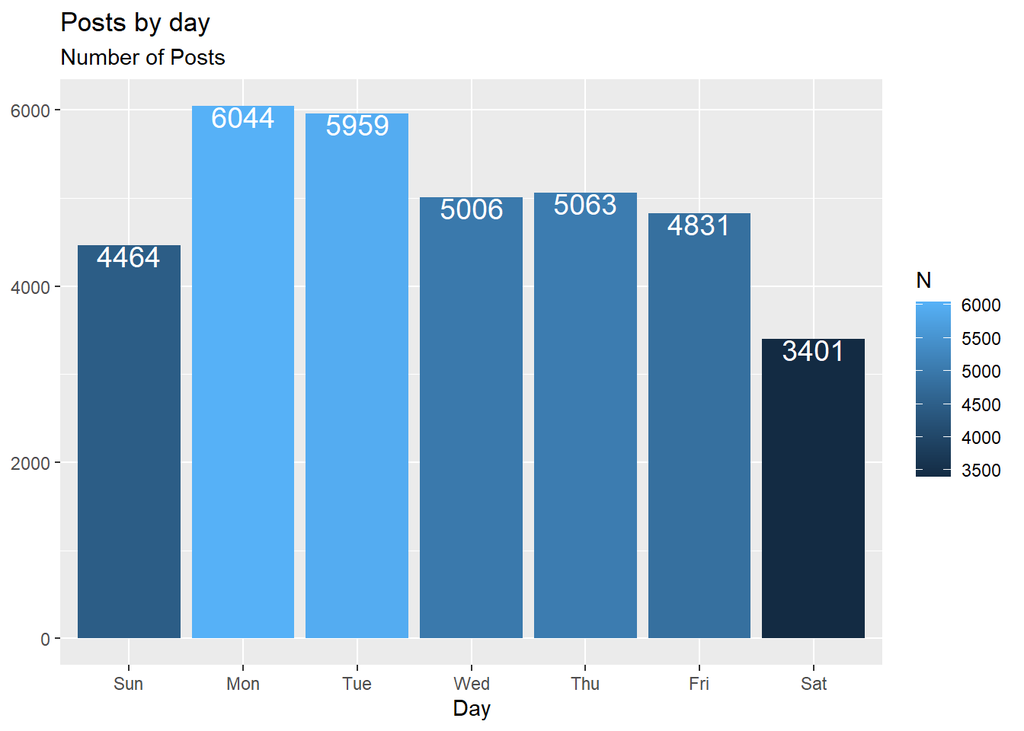

```r
ggplot(df[,.N,by=post_day],aes(x = post_day,y = N,fill=N,label=round(N,2)))+
  geom_bar(stat = "identity")+
  labs(title="Posts by day",subtitle="Number of Posts")+
  xlab("Day")+
  ylab(NULL)+
  geom_text(size=5, vjust=1, color="white")
```

#### Inference

- It can be seen from the graph that the Monday recorded the highest number of comments in comparison to the other days in a week. The lowest number of comments were recorded on Saturday

#### **Top 20 Authors as per the number of posts**

```r
top_author<-df[,.N,by=comment_author][order(-N)][1:20]
top_author
```

```
##           comment_author    N
##  1:              unknown 1958
##  2:        AutoModerator  370
##  3:         lovememychem  158
##  4:            Eggsegret  120
##  5:     JenniferColeRhuk   97
##  6:      collegemathchef   83
##  7:         Juicyjackson   80
##  8:       ChaplnGrillSgt   79
##  9:            jzero4242   79
## 10:             Texden29   76
## 11:         BlazingSaint   72
## 12:        commandante44   69
## 13:                 tb0x   68
## 14:          skeebidybop   67
## 15:              bluGill   67
## 16: Viewfromthe31stfloor   65
## 17:       UncleLongHair0   63
## 18:                garfe   62
## 19:         Hothabanero6   58
## 20:              Dakke97   58
```

#### **Top 20 Authors as per the posts score**

```r
df[,.("Post_Score"=sum(post_score,na.rm=T)),by=comment_author][order(-Post_Score)][1:20]
```

```
##         comment_author Post_Score
##  1:            unknown    9483070
##  2:        skeebidybop     957048
##  3:      AutoModerator     895923
##  4:       Juicyjackson     822167
##  5:           Texden29     660588
##  6:          Eggsegret     640602
##  7:     Dustin_Bromain     633643
##  8:     ChaplnGrillSgt     598914
##  9:          Diegobyte     596339
## 10:        RickDawkins     590139
## 11:    collegemathchef     569674
## 12: yeahthatskindacool     501922
## 13:       lovememychem     491578
## 14:   maybenextyearCLE     490485
## 15:     hollowsinchris     489720
## 16:             Liface     437650
## 17:              garfe     413090
## 18:        ErebusShark     394211
## 19:            vamp111     391103
## 20:         WingyPilot     384405
```

### Cleaning the data of HTML tags, hashtags , punctuations and special characters

```r
#Replacing the URLS
df_data <- df %>% mutate(comment_body = str_replace_all(comment_body, "//^(?:http(?:s)?:\\//\\//)?(?:[^\\.]+\\.)?[a-zA-Z0-9]\\.com(\\//.*)?$", ""))

df_Vaccine_file <- df_Vaccine_file %>% mutate(comment_body = str_replace_all(comment_body, "//^(?:http(?:s)?:\\//\\//)?(?:[^\\.]+\\.)?[a-zA-Z0-9]\\.com(\\//.*)?$", ""))

#Replacing HTML tags
df_data <- df_data %>% mutate(comment_body = str_replace_all(comment_body, "(<br />)+", ""))
df_Vaccine_file <- df_Vaccine_file %>% mutate(comment_body = str_replace_all(comment_body, "(<br />)+", ""))


#Remove # in hashtags
df_data <- df_data %>% mutate(comment_body = str_replace_all(comment_body, "#([^\\s]+)", "\1"))
df_Vaccine_file <- df_Vaccine_file %>% mutate(comment_body = str_replace_all(comment_body, "#([^\\s]+)", "\1"))


#Remove punctuations,numbers and special characters
df_data <- df_data %>% mutate(comment_body = str_replace_all(comment_body, "^[a-zA-Z0-9]*$", ""))
df_Vaccine_file <- df_Vaccine_file %>% mutate(comment_body = str_replace_all(comment_body, "^[a-zA-Z0-9]*$", ""))
```

### **NLP Procedure**

#### The below procedure returns clean tokens. It also removes stop words and rare words that are part of the text

```r
get_cleaned_tokens <- function(df_data,redditname) {
  if (redditname == 'all') {
    df_data <- df_data
  } else {
    df_data <- subset(df_data,subreddit == redditname)
  }

  tokens <- df_data %>% unnest_tokens(output = word, input = comment_body)
  tokens %>%  count(word,sort = TRUE)

  #get_stopwords()
  #get stop words
  sw = get_stopwords()
  #cleaned_tokens <- tokens %>%  anti_join(get_stopwords())
  cleaned_tokens <- tokens %>%  filter(!word %in% sw$word)

  nums <- cleaned_tokens %>% filter(str_detect(word, "^[0-9]")) %>% select(word) %>% unique()
  #head(nums)
  cleaned_tokens <- cleaned_tokens %>%   anti_join(nums, by = "word")
  #head(cleaned_tokens)

  cleaned_tokens %>%
    count(word, sort = T) %>%
    rename(word_freq = n) %>%
    ggplot(aes(x=word_freq)) +
    geom_histogram(aes(y=..count..), color="black", fill="blue", alpha=0.3) +
    scale_x_continuous(breaks=c(0:5,10,100,500,10e3), trans="log1p", expand=c(0,0)) +
    scale_y_continuous(breaks=c(0,100,1000,5e3,10e3,5e4,10e4,4e4), expand=c(0,0)) +
    theme_bw()

  rare <- cleaned_tokens %>%   count(word) %>%  filter(n<10) %>%  select(word) %>% unique()
  head(rare)

  rare <- cleaned_tokens %>%
    count(word) %>%
    filter(n<10) %>%
    select(word) %>% unique()

  alpha_remove <- cleaned_tokens %>% filter(str_detect(word, "^[Ã¢|s|t|r|gt|http]$")) %>%   select(word) %>% unique()


  cleaned_tokens <- cleaned_tokens %>%
    filter(!word %in% rare$word)
  length(unique(cleaned_tokens$word))

  cleaned_tokens <- cleaned_tokens %>% filter(!word %in% alpha_remove$word)
  return(cleaned_tokens)
}
```

### **Word Cloud for the reddit comments**

```r
cleaned_tokens = get_cleaned_tokens(df_data,'all')
cleaned_tokens_Pfizer = get_cleaned_tokens(df_Vaccine_file,'PfizerVaccine')
cleaned_tokens_Astrazeneca = get_cleaned_tokens(df_Vaccine_file,'Astrazeneca')
cleaned_tokens_Moderna = get_cleaned_tokens(df_Vaccine_file,'Moderna')
```

### **Plotting the word cloud related to Pfizer dataset**

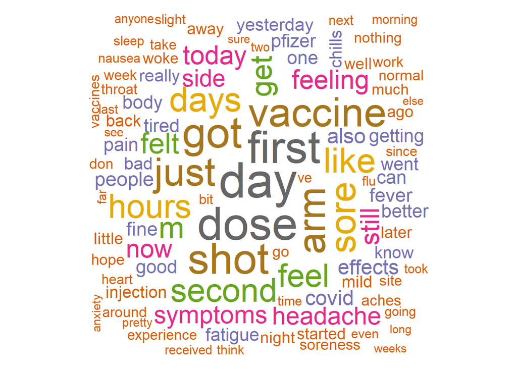

```r
pal <- brewer.pal(8,"Dark2")
cleaned_tokens_Pfizer %>%
  count(word) %>%
  with(wordcloud(word, n, random.order = FALSE, max.words = 100, colors=pal))
```

### **Plotting the word cloud related to Astrazeneca dataset**

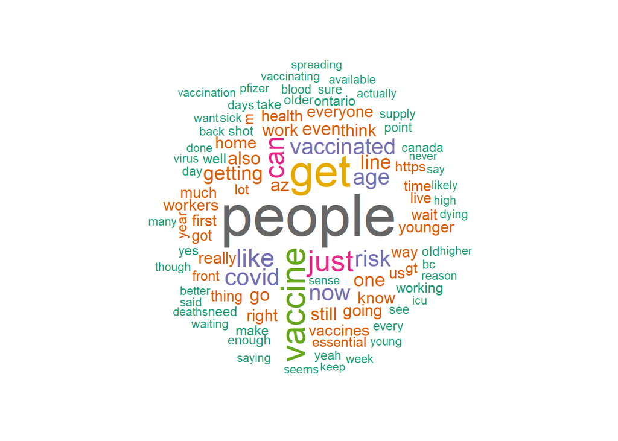

```r
pal <- brewer.pal(8,"Dark2")
cleaned_tokens_Astrazeneca %>%
  count(word) %>%
  with(wordcloud(word, n, random.order = FALSE, max.words = 100, colors=pal))
```

### **Plotting the word cloud related to Moderna dataset**

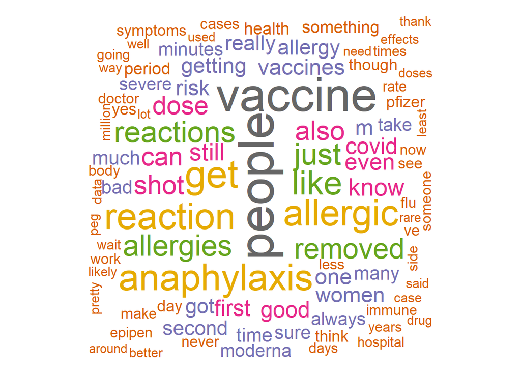

```r
pal <- brewer.pal(8,"Dark2")
cleaned_tokens_Moderna %>%
  count(word) %>%
  with(wordcloud(word, n, random.order = FALSE, max.words = 100, colors=pal))
```

### **Plotting the 100 most common words in the Reddit comments**

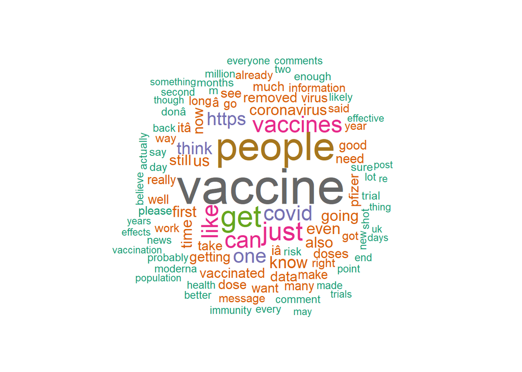

```r
pal <- brewer.pal(8,"Dark2")
cleaned_tokens %>%
  count(word) %>%
  with(wordcloud(word, n, random.order = FALSE, max.words = 100, colors=pal))
```

### **Sentiment Analysis**

```r
get_sentiments("nrc")
```

```
## # A tibble: 13,901 x 2
##    word        sentiment
##    <chr>       <chr>
##  1 abacus      trust
##  2 abandon     fear
##  3 abandon     negative
##  4 abandon     sadness
##  5 abandoned   anger
##  6 abandoned   fear
##  7 abandoned   negative
##  8 abandoned   sadness
##  9 abandonment anger
## 10 abandonment fear
## # ... with 13,891 more rows
```

```r
get_sentiments("afinn")
```

```
## # A tibble: 2,477 x 2
##    word       value
##    <chr>      <dbl>
##  1 abandon       -2
##  2 abandoned     -2
##  3 abandons      -2
##  4 abducted      -2
##  5 abduction     -2
##  6 abductions    -2
##  7 abhor         -3
##  8 abhorred      -3
##  9 abhorrent     -3
## 10 abhors        -3
## # ... with 2,467 more rows
```

```r
sent_reviews = cleaned_tokens %>%
  left_join(get_sentiments("nrc")) %>%
  rename(nrc = sentiment) %>%
  left_join(get_sentiments("bing")) %>%
  rename(bing = sentiment) %>%
  left_join(get_sentiments("afinn")) %>%
  rename(afinn = value)
```

### **Most positive and negative words**

```r
bing_word_counts <- sent_reviews %>%
  filter(!is.na(bing)) %>%
  count(word, bing, sort = TRUE)

head(bing_word_counts,5)
```

```
##      word     bing    n
## 1:   good positive 8915
## 2:   like positive 4369
## 3:   risk negative 3996
## 4:    bad negative 3535
## 5: pretty positive 3140
```

### **Graph of most positive and negative words**

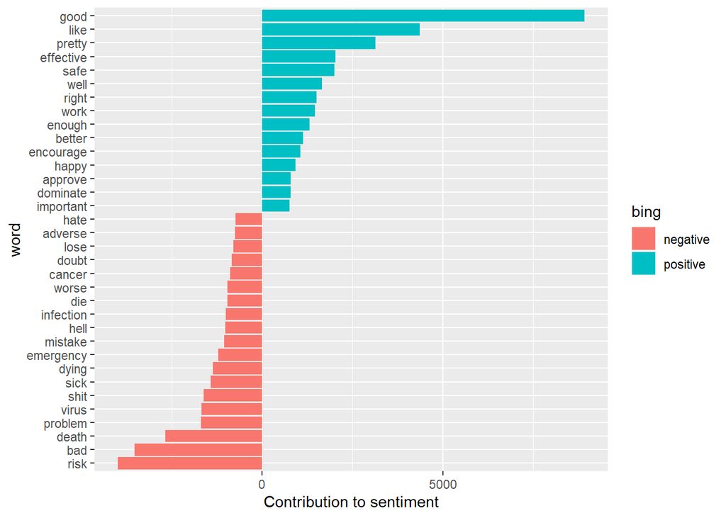

```r
bing_word_counts %>%
  filter(n > 700) %>%
  mutate(n = ifelse(bing == "negative", -n, n)) %>%
  mutate(word = reorder(word, n)) %>%
  ggplot(aes(word, n, fill = bing)) +  geom_col() +  coord_flip() +  labs(y = "Contribution to sentiment")
```

#### Inference

- It can be seen from the graph that the most positive words are good, like, pretty, effective,safe and the most negative words are risk, bad, death, problem, virus

### **Tokenizing by n-grams**

```r
df_data$comment_body<-as.character(df_data$comment_body)
bigrams <- df_data %>%  unnest_tokens(bigram, comment_body, token = "ngrams", n = 2)
```

#### **Most common bi-grams**

```r
bigrams %>%  count(bigram, sort = TRUE)
```

```
##                       bigram    n
##      1:               in the 4801
##      2:               of the 4715
##      3:          the vaccine 4150
##      4:                to be 3216
##      5:              will be 2377
##     ---
## 360668:        zuckerburg so    1
## 360669:       zuckerburg too    1
## 360670:       zulassung soll    1
## 360671: zuvx8x5dq3g learning    1
## 360672:              zynga i    1
```

#### **Filtering by n-grams**

```r
bigrams_separated <- bigrams %>%
  separate(bigram, c("word1", "word2"), sep = " ")
bigrams_filtered <- bigrams_separated %>%
  filter(!word1 %in% stop_words$word) %>%
  filter(!word2 %in% stop_words$word)
```

#### **Bi-gram counts**

```r
bigrams_filtered %>%   count(word1, word2, sort = TRUE)
```

```
##              word1          word2    n
##     1:        <NA>           <NA> 2024
##     2:       covid             19  999
##     3:       https www.reddit.com  903
##     4:     message        compose  882
##     5: coronavirus           wiki  831
##    ---
## 90365:    zoonotic        viruses    1
## 90366:    žpfizerâ              œ    1
## 90367:        zuck     apparently    1
## 90368:   zulassung           soll    1
## 90369: zuvx8x5dq3g       learning    1
```

```r
bigram_united <- bigrams_filtered %>%
  unite(bigram, word1, word2, sep = " ")
bigram_counts <- bigram_united %>%
  count(bigram, sort = TRUE)

bigram_counts=bigram_counts[-1,]
```

#### **Visualization of Top-10 bigram words**

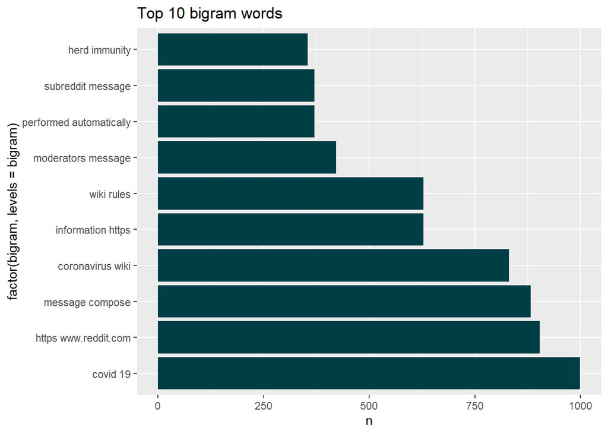

```r
bigram_counts %>% arrange(desc(n))%>% head(10)%>%ggplot(aes(x=factor(bigram,levels=bigram),y=n))+geom_bar(stat="identity",fill="#003E45")+labs(title="Top 10 bigram words")+coord_flip()
```

#### **Document Term Matrix**

```r
word_counts_by_doc_id <- cleaned_tokens %>%
  group_by(comment_id) %>%
  count(word, sort = TRUE)

review_dtm <- word_counts_by_doc_id %>%
  cast_dtm(comment_id, word, n)

review_dtm
```

```
## <<DocumentTermMatrix (documents: 34223, terms: 5609)>>
## Non-/sparse entries: 542715/191414092
## Sparsity           : 100%
## Maximal term length: 22
## Weighting          : term frequency (tf)
```

```r
#Topic Modeling using LDA

library(topicmodels)
lda8 <- LDA(review_dtm, k = 8, control = list(seed = 1234))
terms(lda8, 20)
```

```
##       Topic 1     Topic 2     Topic 3          Topic 4      Topic 5
##  [1,] "vaccine"   "like"      "coronavirus"    "people"     "doses"
##  [2,] "data"      "just"      "removed"        "get"        "can"
##  [3,] "dose"      "iâ"        "https"          "think"      "well"
##  [4,] "trial"     "m"         "message"        "going"      "vaccines"
##  [5,] "one"       "one"       "information"    "itâ"        "million"
##  [6,] "pfizer"    "got"       "please"         "know"       "immunity"
##  [7,] "moderna"   "thing"     "comment"        "still"      "population"
##  [8,] "effective" "never"     "made"           "vaccinated" "months"
##  [9,] "trials"    "good"      "believe"        "now"        "end"
## [10,] "cases"     "bad"       "comments"       "donâ"       "days"
## [11,] "efficacy"  "something" "post"           "want"       "much"
## [12,] "side"      "anything"  "wiki"           "even"       "first"
## [13,] "oxford"    "anti"      "www.reddit.com" "back"       "shot"
## [14,] "group"     "yeah"      "compose"        "really"     "weeks"
```

[output cut: 27 more lines]

```r
lda8_betas <- broom::tidy(lda8)
lda8_betas
```

```
## # A tibble: 44,872 x 3
##    topic term            beta
##    <int> <chr>          <dbl>
##  1     1 https       3.17e-10
##  2     2 https       2.90e-27
##  3     3 https       3.17e- 2
##  4     4 https       5.13e-29
##  5     5 https       1.00e-16
##  6     6 https       2.17e- 2
##  7     7 https       9.56e-17
##  8     8 https       3.81e-18
##  9     1 reinfection 8.12e-28
## 10     2 reinfection 5.56e-38
## # ... with 44,862 more rows
```

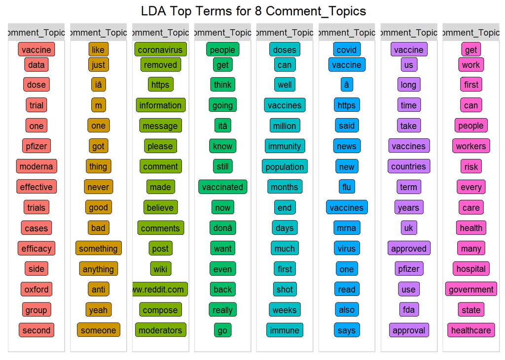

```r
library(ggrepel)
terms_in_comments <- lda8_betas %>%
  group_by(topic) %>%
  top_n(5, beta) %>%
  ungroup() %>%
  arrange(topic, -beta)

terms_per_comments <- function(lda_model, num_words) {


  topics_tidy <- tidy(lda_model, matrix = "beta")
  top_terms <- topics_tidy %>%
    group_by(topic) %>%
    arrange(topic, desc(beta)) %>%
    slice(seq_len(num_words)) %>%
    arrange(topic, beta) %>%
    mutate(row = row_number()) %>%
    ungroup() %>%
    mutate(topic = paste("Comment_Topic", topic, sep = " "))
  title <- paste("LDA Top Terms for", k, "Comment_Topics")
  comments_wordchart(top_terms, top_terms$term, title)
}

comments_wordchart <- function(data, input, title) {
  data %>%

    ggplot(aes(as.factor(row), 1, label = input, fill = factor(topic) )) +

    geom_point(color = "transparent") +

    geom_label_repel(nudge_x = .2,
                     direction = "y",
                     box.padding = 0.1,
                     segment.color = "transparent",
                     size = 3) +
    facet_grid(~topic) +
    theme_comments() +
    theme(axis.text.y = element_blank(), axis.text.x = element_blank(),
          axis.title.x = element_text(size = 9),
          panel.grid = element_blank(), panel.background = element_blank(),
          panel.border = element_rect("lightgray", fill = NA),
          strip.text.x = element_text(size = 9)) +
    labs(x = NULL, y = NULL, title = title) +

    ggtitle(title) +
    coord_flip()
}

theme_comments <- function()
{
  theme(plot.title = element_text(hjust = 0.5),
        axis.text.x = element_blank(),
        axis.ticks = element_blank(),
        panel.grid.major = element_blank(),
        panel.grid.minor = element_blank(),
        legend.position = "none")
}
k <-8
terms_per_comments(lda8,15)
```

### **TF-IDF**

```r
tfidf <- word_counts_by_doc_id %>%
  bind_tf_idf(word, comment_id, n)

#kable(head(tfidf,5))
head(tfidf,5)
```

```
## # A tibble: 5 x 6
## # Groups:   comment_id [3]
##   comment_id word            n     tf   idf tf_idf
##   <chr>      <chr>       <int>  <dbl> <dbl>  <dbl>
## 1 gig8t18    https          58 0.0885  2.74  0.243
## 2 gig8t18    reinfection    38 0.0580  6.59  0.382
## 3 gig8t18    covid          37 0.0565  2.47  0.140
## 4 gfcr9su    https          36 0.0893  2.74  0.245
## 5 gipjf1j    â              32 0.0494  3.52  0.174
```

- From TF-IDF we can infer the words that are important in the particular document but not in the corpus

```r
library(dplyr)
df_data %>%
  select(comment_body) %>%
  sentimentr::get_sentences() %>%
  sentimentr::sentiment() %>%
  mutate(characters = nchar(stripWhitespace(comment_body))) %>%
  filter(characters >1 ) -> bounded_sentences

summary(bounded_sentences$sentiment)
```

```
##     Min.  1st Qu.   Median     Mean  3rd Qu.     Max.
## -2.07942 -0.10000  0.00000  0.02481  0.17889  2.31425
```

### **Extracting positive and negative sentiments**

```r
bounded_sentences %>% filter(between(sentiment,-1,1)) ->  bounded_sentences
sentiment_densities <- with(density(bounded_sentences$sentiment), data.frame(x, y))
```

### **Visualization of sentiments from the Reddit Comments**

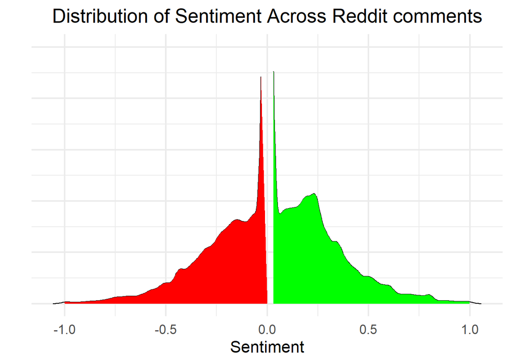

```r
ggplot(sentiment_densities, aes(x = x, y = y)) +
  geom_line() +
  geom_area(mapping = aes(x = ifelse(x >=0 & x<=1 , x, 0)), fill = "green") +
  geom_area(mapping = aes(x = ifelse(x <=0 & x>=-1 , x, 0)), fill = "red") +
  scale_y_continuous(limits = c(0,2.5)) +
  theme_minimal(base_size = 16) +
  labs(x = "Sentiment",
       y = "",
       title = "Distribution of Sentiment Across Reddit comments") +
  theme(plot.title = element_text(hjust = 0.5),
        axis.text.y=element_blank()) -> gg

plot(gg)
```

### **NLP summary**

Natural Language Processing allows machine to understand the text. We have implemented following in NLP: * Tokenization helps us to cut the corpus into pieces known as tokens. For further processing, this tokens list is provided.

### **Final Remarks**

#### **References**

- We used the following references for our project
- [1] [R markdown](https://monashbioinformaticsplatform.github.io/2017-11-16-open-science-training/topics/rmarkdown.html)
- [2] [R markdown cheatsheet](https://github.com/rstudio/cheatsheets/raw/master/rmarkdown-2.0.pdf)
- [3] [Data cleaning](https://github.com/rfordatascience/tidytuesday/tree/master/data/2019/2019-04-23)
- [4] [ggplot2 Visualizations](http://r-statistics.co/Top50-Ggplot2-Visualizations-MasterList-R-Code.html#Ordered%20Bar%20Chart)